# PS 812

Section 6: Visualizing Distributions and Conditional Means

John Hicks

Dept. of Political Science, UW-Madison

2026-10-16

# Today

## Today

**1. One variable**

Histograms, density plots, and ECDFs

**2. Two variables**

Scatterplots and overplotting

**3. Conditional means**

Binned scatterplots: an estimate of the CEF that is just a mean in bins

**4. Putting lines on graphs**

`geom_hline()`, `geom_abline()`, and `geom_segment()` for lines we compute ourselves

## Data

Two datasets we’ve already seen:

- **County returns, 2016** (week 4 lecture): Clinton’s vote share and the % non-Hispanic white in each of ~3,100 counties
- **CES 2025** (section 2): age, party ID, ideology, and Trump approval for 17,000 respondents

```r
election <- read_csv("data/prez_election_2016_vote.csv") |>
  mutate(voteshare = 100 * candidatevotes / totalvotes) |>
  filter(!is.na(voteshare), !is.na(pctWhiteNH))

ces <- read_csv("data/ces25_viz.csv")
```

## The grammar of ggplot

Every plot is built from the same pieces:

- **Data**: a data frame, one row per observation
- **Aesthetics** (`aes()`): which columns map to `x`, `y`, `colour`, `fill`, …
- **Geoms**: what to draw (`geom_point()`, `geom_histogram()`, `geom_line()`, …)
- **Layers** are stacked with `+`. Each layer can bring **its own data**

```r
ggplot(data, aes(x = x, y = y)) +
  geom_point() +                           # layer 1: the raw data
  geom_point(data = other_data, ...) +     # layer 2: a different data frame
  labs(x = "...", y = "...")
```

That last point is most of today: compute something with `dplyr`, then add it as a layer.

# One variable

## Histograms

```r
ggplot(election, aes(x = voteshare)) +
  geom_histogram(binwidth = 2, boundary = 0, fill = "grey60", colour = "white") +
  labs(x = "Clinton vote share (%)", y = "Counties")
```

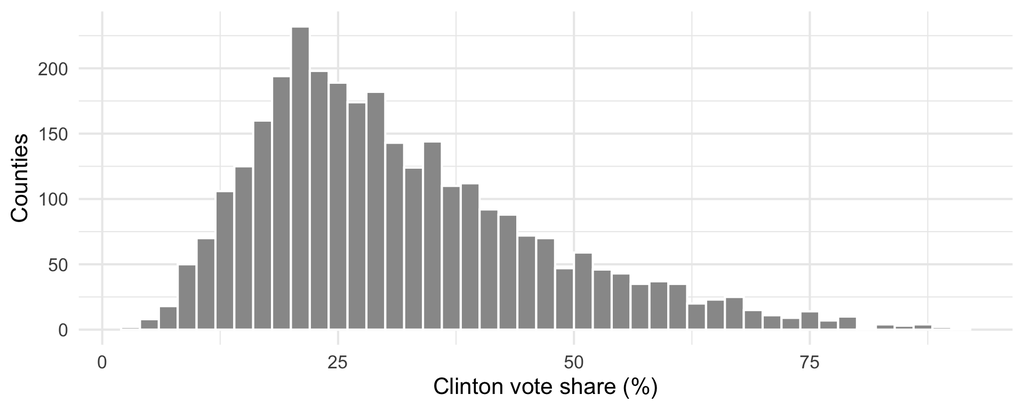

- Cut the support into bins, **count** the observations in each
- Most counties went heavily for Trump. A long right tail of Clinton counties

## The bin width is a choice

[figure not shown]

- Too narrow: every bump is noise
- Too wide: the shape disappears
- Same data, three different pictures. Nothing here is “the” histogram

## Counts to densities

Put the histogram on the **density** scale so the bars’ area sums to 1:

```r
ggplot(election, aes(x = voteshare)) +
  geom_histogram(aes(y = after_stat(density)), binwidth = 2, boundary = 0,
                 fill = "grey80", colour = "white") +
  geom_density(colour = uw_red, linewidth = 1.2) +
  labs(x = "Clinton vote share (%)", y = "Density")
```

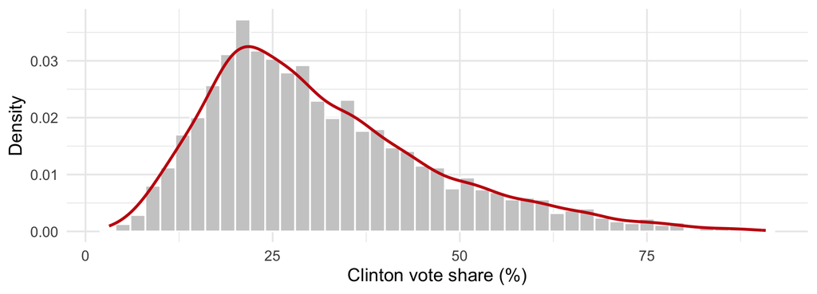

- `after_stat(density)`: height = share in bin / bin width
- `geom_density()`: a **smoothed** histogram

## What a density plot does

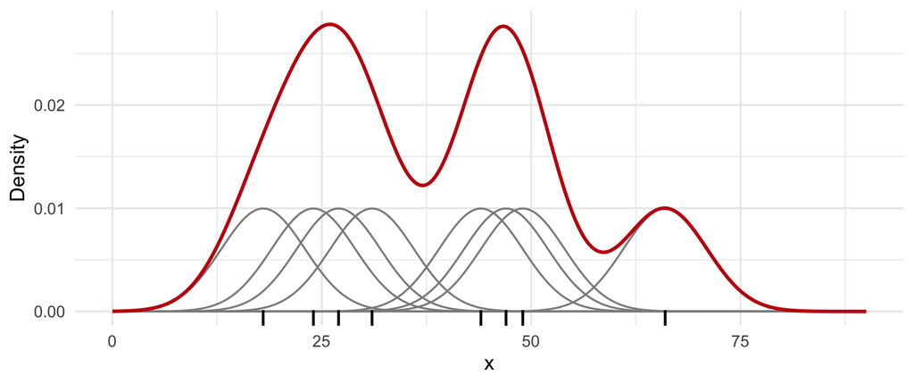

- Put a small normal bump on every observation, each with area $1/n$
- Add up the bumps. The total still integrates to 1
- The bump’s width (the **bandwidth**) plays the role of the bin width

## The bandwidth is also a choice

```r
ggplot(election, aes(x = voteshare)) +
  geom_density(adjust = 0.2, colour = "grey60") +
  geom_density(adjust = 1,   colour = uw_red, linewidth = 1.2) +
  geom_density(adjust = 4,   colour = "black", linetype = "dashed") +
  labs(x = "Clinton vote share (%)", y = "Density")
```

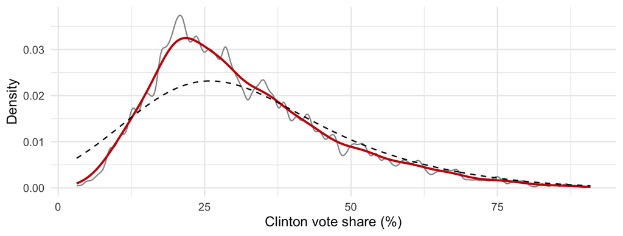

- `adjust` multiplies R’s default bandwidth: 0.2 (grey), 1 (red), 4 (dashed)
- Same tradeoff as bins: too wiggly vs. too smooth

## Comparing groups

Overlapping histograms are hard to read. Overlapping densities are easy:

```r
ces |>
  filter(pid3 != "Independent/Other") |>
  ggplot(aes(x = age, fill = pid3)) +
  geom_density(alpha = 0.4, colour = NA) +
  scale_fill_manual(values = c(Democrat = "#2166ac", Republican = "#b2182b")) +
  labs(x = "Age", y = "Density", fill = NULL)
```

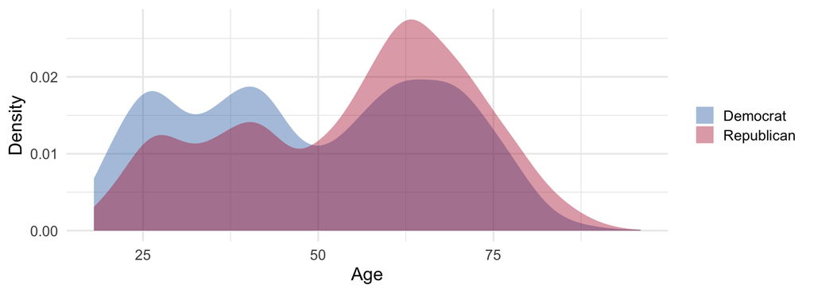

- Each density integrates to 1 **within its group**: it shows shape, not group size

## Survey weights

The CES comes with weights. Pass them as an aesthetic:

```r
ces |>
  filter(pid3 != "Independent/Other") |>
  ggplot(aes(x = age, colour = pid3)) +
  geom_density(linetype = "dashed") +                       # unweighted
  geom_density(aes(weight = weight / sum(weight)), linewidth = 1.2) +  # weighted
  scale_colour_manual(values = c(Democrat = "#2166ac", Republican = "#b2182b")) +
  labs(x = "Age", y = "Density", colour = NULL)
```

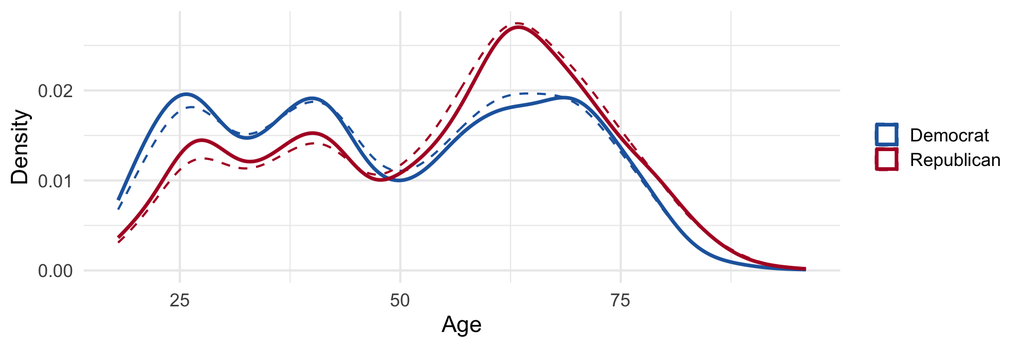

- `geom_density()` wants weights that sum to 1 within each group, or it warns. Normalizing over the full sample is close enough for a picture

## The empirical CDF

$$\hat F(x) = \frac{1}{n} \sum_{i=1}^{n} \mathbf{1}(X_i \le x)$$

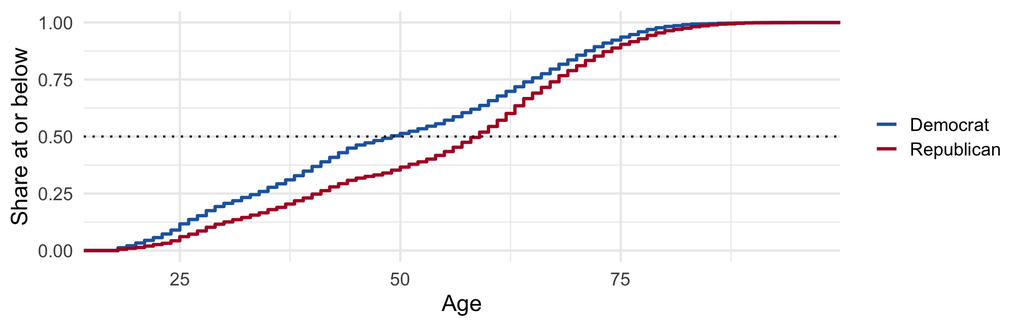

```r
ces |>
  filter(pid3 != "Independent/Other") |>
  ggplot(aes(x = age, colour = pid3)) +
  stat_ecdf(linewidth = 1.1) +
  geom_hline(yintercept = 0.5, linetype = "dotted") +
  scale_colour_manual(values = c(Democrat = "#2166ac", Republican = "#b2182b")) +
  labs(x = "Age", y = "Share at or below", colour = NULL)
```

- No bins, no bandwidth: it’s just a share. Read medians off the dotted line

# Two variables

## Scatterplots

```r
ggplot(election, aes(x = pctWhiteNH, y = voteshare)) +
  geom_point() +
  labs(x = "% non-Hispanic white", y = "Clinton vote share (%)")
```

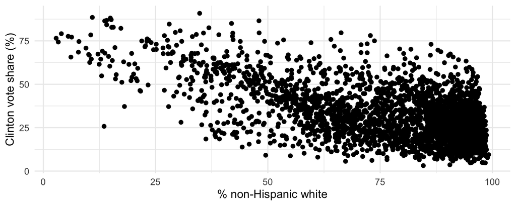

- 3,000 points, most of them stacked on top of each other in the bottom right

## Fixing overplotting

```r
ggplot(election, aes(x = pctWhiteNH, y = voteshare)) +
  geom_point(size = 1, alpha = 0.2) +
  labs(x = "% non-Hispanic white", y = "Clinton vote share (%)")
```

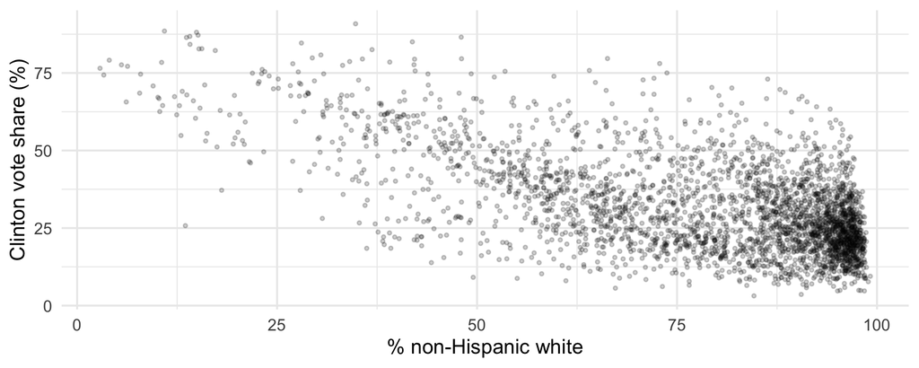

- Smaller, transparent points: dark regions are where the data are dense
- The relationship is clearly negative. But **how** does the average change with $X$?

## Discrete outcomes are worse

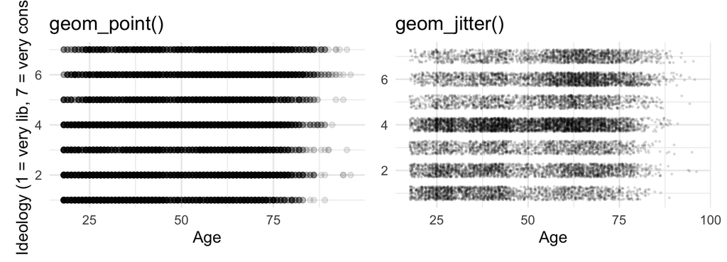

- With a 7-point $Y$, every point sits on one of seven lines
- `geom_jitter()` adds a little noise so you can see the mass. Still hard to see the trend
- The scatterplot shows the joint distribution. We want the **conditional mean**

# Conditional means

## Back to the CEF

From week 4:

$$\mu(x) = \mathbb{E}[Y \mid X = x]$$

- Give it a value of $X$, it returns the mean of $Y$ **among units with that value**
- So the sample analog is just: **take the units with $X = x$, and average their $Y$**
- No model, no line, no assumptions about shape

## Discrete $X$: a mean at each value

```r
ideo_by_pid <- ces |>
  filter(!is.na(pid7), !is.na(ideo7)) |>
  group_by(pid7) |>
  summarise(ideo = mean(ideo7), n = n())
```

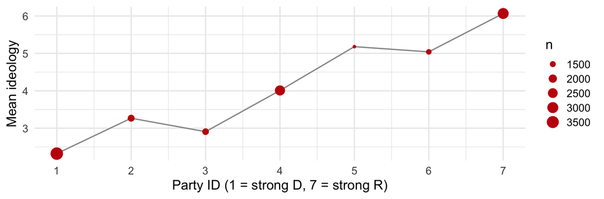

```r
ggplot(ideo_by_pid, aes(x = pid7, y = ideo)) +
  geom_line(colour = "grey60") +
  geom_point(aes(size = n), colour = uw_red) +
  scale_x_continuous(breaks = 1:7) +
  labs(x = "Party ID (1 = strong D, 7 = strong R)", y = "Mean ideology")
```

- Seven means, one per value of $X$. Point size is the number of respondents
- Not even monotone: leaners (3, 5) are more ideological than weak partisans (2, 6). A line would miss this

## Continuous $X$: no two counties share a value

- No two counties have exactly the same % white, so we can’t average “at” $x$
- Instead, **average near $x$**:
  1. Cut $X$ into bins
  2. Within each bin, average $X$ and average $Y$
  3. Plot the bin averages

```r
binned <- election |>
  mutate(bin = ntile(pctWhiteNH, 20)) |>          # 20 bins, equal counts
  group_by(bin) |>
  summarise(x_lo = min(pctWhiteNH), x_hi = max(pctWhiteNH),
            x = mean(pctWhiteNH), y = mean(voteshare), n = n())
```

- That’s a **binned scatterplot**

## Step 1: the data

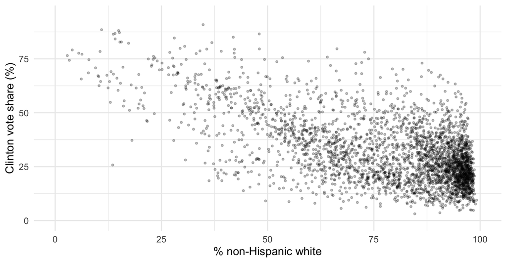

## Step 2: cut $X$ into bins

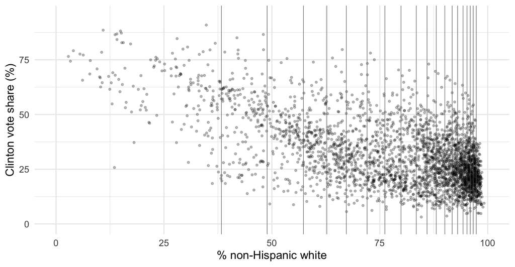

- 20 bins with ~155 counties each. Bins are narrow where the data are dense

## Step 3: the mean of $Y$ in each bin

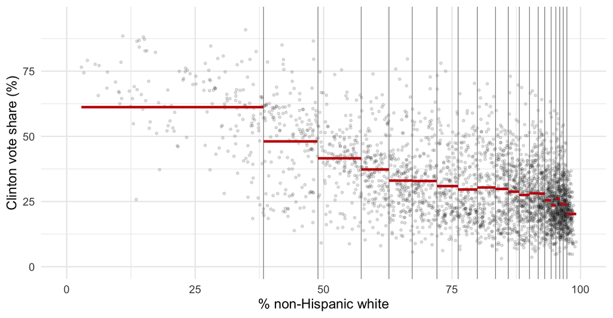

- A flat segment across each bin, at that bin’s average Clinton share

## Step 4: one point per bin

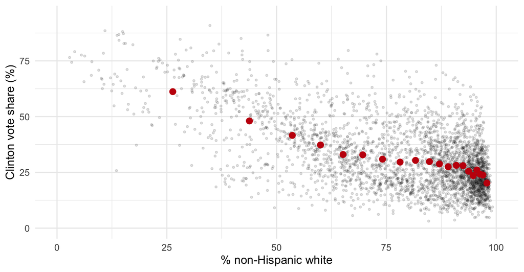

- Each point sits at $(\bar x_{\text{bin}}, \bar y_{\text{bin}})$. That’s the whole binned scatterplot

## The code for steps 3 and 4

```r
ggplot(election, aes(x = pctWhiteNH, y = voteshare)) +
  geom_point(size = 1, alpha = 0.12) +
  # step 3: a segment we define ourselves, from the bin's min to its max
  geom_segment(data = binned, aes(x = x_lo, xend = x_hi, y = y, yend = y),
               colour = uw_red, linewidth = 1.4) +
  # step 4: one point per bin
  geom_point(data = binned, aes(x = x, y = y), colour = uw_red, size = 3.5)
```

- Two layers with a **different data frame** from the base plot
- `geom_segment()` needs four aesthetics: `x`, `xend`, `y`, `yend`

## It’s just a mean in bins

The bin means average back to the overall mean (the law of iterated expectations):

$$\bar Y = \sum_{b} \frac{n_b}{n}\, \bar Y_b$$

```r
mean(election$voteshare)
```

```
[1] 31.54231
```

```r
sum(binned$n * binned$y) / sum(binned$n)
```

```
[1] 31.54231
```

- Weight each bin by its share of the data, $n_b / n$, the sample analog of $P(X \in \text{bin } b)$
- Equal-count bins make all the weights the same, so here a plain `mean(binned$y)` works too

## How many bins?

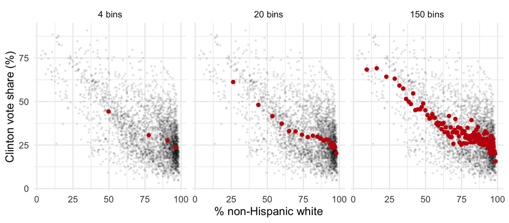

- Few bins: smooth, but each mean averages over very different counties
- Many bins: follows the data closely, but each mean is based on ~20 counties, so it’s noisy
- The same tradeoff as the bin width and the bandwidth. More on this (**bias vs. variance**) in lecture this week

## Equal width or equal count?

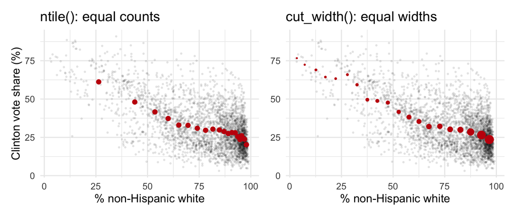

- Equal counts put more bins where the data are, so every mean is equally precise. But the first bin runs from 3% to 38% white: one mean for very different counties
- Equal widths show the shape over all of $X$, but some bins have only a handful of counties (small points), so their means are noisy

## Binary $Y$: the bin mean is a share

```r
approve_by_age <- ces |>
  filter(!is.na(trump_approve)) |>
  mutate(age_bin = cut_width(age, width = 5, boundary = 15)) |>
  group_by(age_bin) |>
  summarise(age = mean(age), approve = weighted.mean(trump_approve, weight))

ggplot(approve_by_age, aes(x = age, y = approve)) +
  geom_point(colour = uw_red, size = 3) +
  labs(x = "Age", y = "Share approving of Trump")
```

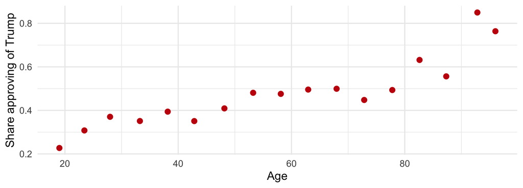

- $\mathbb{E}[Y \mid X = x] = P(Y = 1 \mid X = x)$ when $Y$ is 0/1
- `weighted.mean()` uses the survey weights inside each bin

# Putting lines on graphs

## Lines we define ourselves

| Geom | Draws | Needs |
| --- | --- | --- |
| `geom_hline()` | a horizontal line | `yintercept` |
| `geom_vline()` | a vertical line | `xintercept` |
| `geom_abline()` | any straight line | `intercept`, `slope` |
| `geom_segment()` | a segment between two points | `x`, `xend`, `y`, `yend` |

- None of these fit anything. You compute the numbers, ggplot draws them
- (`geom_smooth()` fits models for you. We’ll hold off until we cover regression)

## The best constant and the best line

From week 4: the best constant predictor is $\mathbb{E}[Y]$, and the best linear predictor is

$$\beta = \frac{\text{Cov}(X, Y)}{\text{Var}(X)} \qquad \alpha = \mathbb{E}[Y] - \beta\, \mathbb{E}[X]$$

Plug in sample means, variances, and covariances:

```r
b <- cov(election$pctWhiteNH, election$voteshare) / var(election$pctWhiteNH)
a <- mean(election$voteshare) - b * mean(election$pctWhiteNH)
c(intercept = a, slope = b)
```

```
 intercept      slope
67.8082553 -0.4616726
```

## Putting it together

```r
ggplot(election, aes(x = pctWhiteNH, y = voteshare)) +
  geom_point(size = 1, alpha = 0.1) +
  geom_hline(yintercept = mean(election$voteshare), linetype = "dashed") +
  geom_abline(intercept = a, slope = b, linewidth = 1.1) +
  geom_point(data = binned, aes(x = x, y = y), colour = uw_red, size = 3) +
  labs(x = "% non-Hispanic white", y = "Clinton vote share (%)")
```

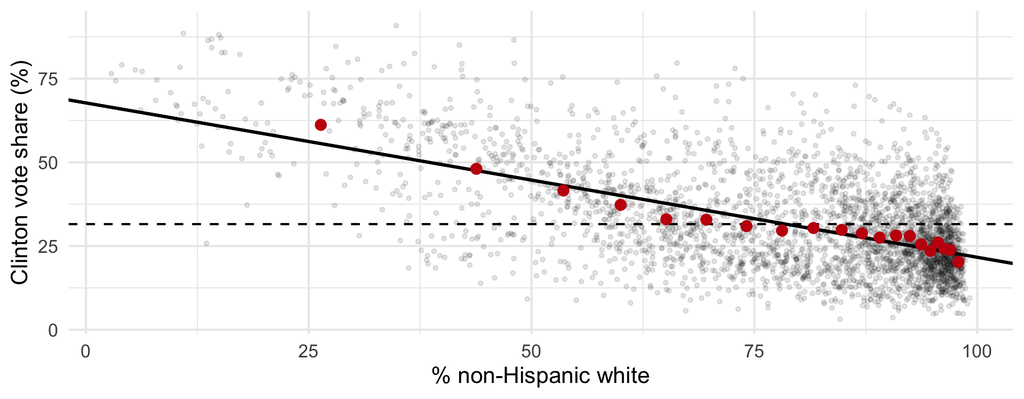

- Dashed: the overall mean. Black: the line from `cov / var`. Red: the bin means
- The line misses the curvature: it’s below the bin means for the least-white counties and above them between about 55% and 80% white

## Annotating

`annotate()` adds a single label or segment without a data frame:

```r
ggplot(binned, aes(x = x, y = y)) +
  geom_point(colour = uw_red, size = 3) +
  geom_abline(intercept = a, slope = b) +
  annotate("text", x = 30, y = 20, label = paste("slope =", round(b, 2)), size = 6) +
  annotate("segment", x = 30, xend = 30, y = 23, yend = a + b * 30 - 1,
           arrow = arrow(length = unit(0.3, "cm"))) +
  labs(x = "% non-Hispanic white", y = "Clinton vote share (%)")
```

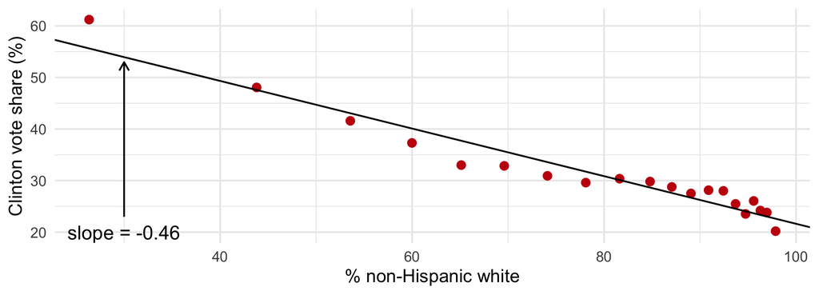

## Recap

- **Histograms and densities** both estimate the shape of a distribution. Bin width and bandwidth control how smooth
- **ECDFs** need no tuning: the share of observations at or below each value
- **Binned scatterplots** estimate the CEF with no model: cut $X$ into bins, average $Y$ in each
- **More bins**: less averaging over different $x$’s, more noise in each mean
- **Lines** (`geom_hline()`, `geom_abline()`, `geom_segment()`): compute it yourself, then draw it

## Flipping the axes: `coord_flip()`

```r
p <- ggplot(approve_by_pid, aes(x = party, y = approve)) +
  geom_col(fill = uw_red) +
  labs(x = NULL, y = "Share approving of Trump")

p                  # left
p + coord_flip()   # right
```

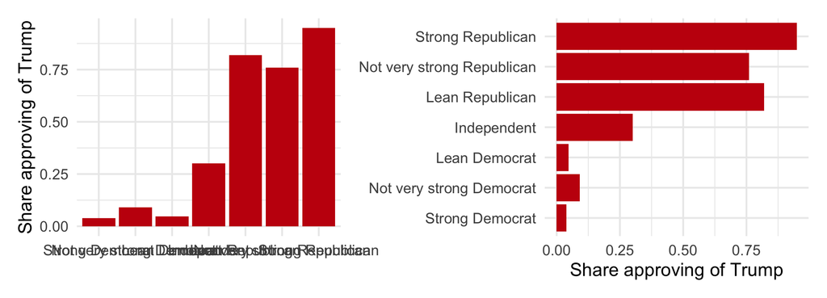

- Swaps what’s drawn on the horizontal and vertical axes. The `aes()` mapping doesn’t change
- Use it when category labels are long: horizontal bars leave room to read them
- You can also just swap the mapping, `aes(x = approve, y = party)`. `coord_flip()` is handy for flipping a plot you’ve already built

# Exercise

## Exercise

Open `ps812_section6_exercise.qmd`.

- Part 1: histograms, densities, and ECDFs
- Part 2: binned scatterplots and lines